# Distribution Parameter Search

08/12/2021

In this tutorial, we will go over searching for the best parameters to describe a distribution. This involves computing maximum likelihood estimation (MLE) in R, which is designed to extract characteristics (parameters) that define an arbitrary distribution.

But first, let us go through the intuition for parameter search.

Let us start simple, below we have defined a standard quadratic equation.

```r
quadratic <- function(x) {
  y <- x**2 - 2
  return(y)
}
```

You are asked to find when this equation is at its minimum. It seems easy enough if you knew anything about quadratic functions, but let us let the computer do the hard work. We can define a bunch of values for x and see when y is low.

```r
B = seq(from = -20, to = 20, by = 0.1)
```

Now we can define a function for minimizing the quadratic equation. All we have done is evaluated our function at each point in B and asked: *at what value of x is y at its minimum*?

```r
minimize_quadratic <- function(quadatric,parameters) {
  min = min(quadratic(parameters))
  min_idx = which.min(quadratic(parameters))
  labs <- c("Minimum for y", "x that minimizes y")
  vals <- c(min,parameters[min_idx])
  output <- rbind(labs,vals)
  return(output)
}
min_quadratic <- minimize_quadratic(quadratic,B)
min_quadratic
```

```
##      [,1]            [,2]
## labs "Minimum for y" "x that minimizes y"
## vals "-2"            "0"
```

Great. We see that the result we get converge with what we would expect.

However, there are problems with this approach in the general case. Without knowing anything about the equation, we might not know whether the parameters we’ve selected include the functions absolute minimum. Maybe we have only found the minimum for the values we selected. Second, this approach is computationally heavy – to get a minimum we may need to evaluate the function by approximating its infinite domain.

We know from beginner calculus that something weird happens at a function’s minimum. Namely, its derivative is zero. When we incorporate our knowledge about derivatives, this problem becomes a lot more tractable.

```r
x <- 0;
dquadratic <- function(x) {
  return(2*x)
}
dquadratic(x)
```

```
## [1] 0
```

Like before, the value that minimizes our quadratic function is the value when its derivative is zero.

However, often in science we are presented with a series of data points (heights, rates of cell proliferation, scores of a personality metric) that are distributed across a population, and we want to know some characteristics about those data points. In other words, we want to find parameters that explain the data points well. However, no equation is available to define these data points; hence, we can’t find the value when the derivative is zero.

Below we are defining a distribution of data points (pick your favourite sciency-sounding output) with unknown mean and standard deviation. We are going to have to find a way to evaluate these parameters.

```r
set.seed(23)
mystery_mu <- runif(1, 8, 14)
mystery_sd <- runif(1,0.5,3)
mystery_data <- rnorm(100,mystery_mu,mystery_sd)
```

While we could easily evaluate the mean and standard deviation of the mystery data, this wouldn’t help us in all cases. For example, in cases where where the underlying distributions are not normally distributed or are composed of many different distributions (combining a normal and uniform distribution). Besides, that is less fun.

The technique we are going to use to compute these optimal parameters is called maximum likelihood. It asks what set of parameters best define our data. It is formalized as: argmax<sub>(Theta1,…,ThetaN)</sub>prod(P(X1,X2,….,XN | Theta1..ThetaN)), where X1,…XN are our data points and Theta1,…ThetaN are the parameters. We want to find Theta1,…,ThetaN that maximize the probability of observing X1,…,XN.

It is interesting to think about what it would mean for parameters to fit our observed data well. It might be easier to think of this example in terms of a normal distribution. Let us stare at a standard normal distribution below.

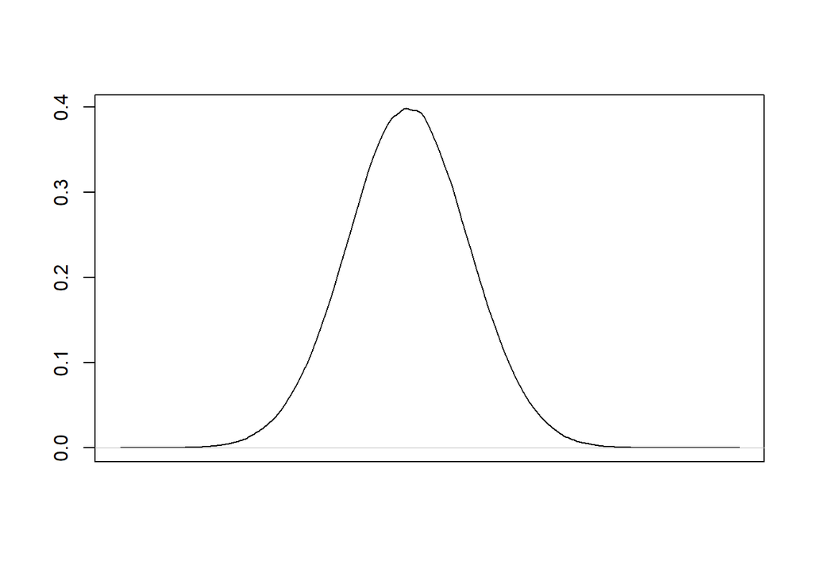

```r
denData <- density(rnorm(1000000,0,1))
plot(denData,xaxt='n', ann=FALSE)
```

And now let’s stare at the formula for the normal distribution.

```r
normal_distribution <- function(x,mu,sigma) {
  (1/(2*pi*sigma)) * exp(-1 * ((x - mu)**2)/(2 * sigma ** 2))
}
```

In this case, our maximum likelihood equation is: argmax<sub>(mu,sigma)</sub>prod(P(denData | mu,sigma)).

Taking the plot and the formula together, we can get a maximum product (multiplication) of probability by having our mu parameter aim for the mean value (the largest value in the normal distribution above) as much as possible, while accommodating a standard deviation that is going to maximize the product of probability when the data point is not the mean.

Taking this together, let’s try to guess the parameter values from our original mystery data.

```r
mulist <- c(7,8,9,10,11,12,13,14)
sigmalist <- c(0.5,1,1.5,2,2.5,3)
max_prob = 0
```

First we define our parameter space for mu and sigma and initialize the maximum product of probabilities at 0.

Next, we will iterate through each parameter (just like in our quadratic equation example) and find which mu and sigma maximize the product of probabilities.

```r
for (i in 1:length(mulist)) {
  for (j in 1:length(sigmalist)) {
    total_probability <- normal_distribution(mystery_data,mulist[i],sigmalist[j])
    if (prod(total_probability) > max_prob) {
      max_prob = prod(total_probability)
      print(max_prob)
      best_mu = mulist[i]
      best_sigma = sigmalist[j]
    }
  }
}
```

```
## [1] 1.472782e-306
## [1] 7.101373e-228
## [1] 2.303046e-195
## [1] 2.337225e-180
## [1] 2.745409e-167
## [1] 7.347405e-161
## [1] 5.400466e-151
## [1] 3.682982e-146
## [1] 1.703766e-130
## [1] 7.707838e-129
## [1] 4.001717e-108
## [1] 2.298029e-106
```

We can see our max product of probability increase until it hits its max at 2.2980286^{-106} at values of mu=12 and sigma=1. Have we figured out our mysterious parameters?

Perhaps, but like in our quadratic example, maybe we have only found the best parameter within the available values. A bigger issue is that by taking the product of probabilities we are quickly hitting a limit of how small a value can be represented by computers. If we were to add more data points to our mystery data (like below), we see that we are unable to find any difference in the product of probability across all parameters.

```r
mystery_data <- rnorm(10000,mystery_mu,mystery_sd)
max_prob = 0

for (i in 1:length(mulist)) {
  for (j in 1:length(sigmalist)) {
    total_probability <- normal_distribution(mystery_data,mulist[i],sigmalist[j])
    if (prod(total_probability) >= max_prob) {
      max_prob = prod(total_probability)
      print(max_prob)
    }
  }
}
```

```
## [1] 0
## [1] 0
## [1] 0
## [1] 0
## [1] 0
## [1] 0
## [1] 0
## [1] 0
## [1] 0
## [1] 0
## [1] 0
## [1] 0
## [1] 0
## [1] 0
## [1] 0
```

[output cut: 33 more lines]

Like before, if we knew the derivative of the normal distribution, we could circumvent this problem. It turns out that we can solve our derivative and limit on numerical processing issue simultaneously.

Smarter people have realized that if you take the natural logarithm of our maximum likelihood equation: argmax<sub>(Theta1,…,ThetaN)</sub>prod(P(X1,X2,….,XN | Theta1..ThetaN)) you make the equation simpler, unlikely to hit the limits of numerical processing, and with the same solutions to Theta1,…,ThetaN.

By using the natural logarithm of the maximum likelihood equation product changes to sum due to law of logarithms. Summing probabilities increases our value by at most 1 per data point, whereas the product of two probability terms could theoretically hit the limit of our numerical computing after a single data point.

```r
ln_normal_distribution <- function(x,mu,sigma) {
  log(1) - log(sqrt(2*pi)) - log(sigma) -  ((x - mu)**2)/(2 * sigma ** 2)
}

min_prob = -Inf

for (i in 1:length(mulist)) {
  for (j in 1:length(sigmalist)) {
    total_probability <- ln_normal_distribution(mystery_data,mulist[i],sigmalist[j])
    if (sum(total_probability) > min_prob) {
      min_prob = sum(total_probability)
      print(min_prob)
      best_mu_ln = mulist[i]
      best_sigma_ln = sigmalist[j]
    }
  }
}
```

```
## [1] -424217.4
## [1] -114679.2
## [1] -60128.42
## [1] -42493.32
## [1] -35230.67
## [1] -31896.6
## [1] -28877.22
## [1] -27484.49
## [1] -25138.79
## [1] -24123.77
## [1] -20516.35
## [1] -20211.53
## [1] -15843.03
```

```r
print(best_mu_ln == best_mu)
```

```
## [1] FALSE
```

```r
print(best_sigma_ln == best_sigma)
```

```
## [1] TRUE
```

Furthermore, applying the natural logarithm to the normal distribution also simplifies taking its derivative. Without going into detail, taking the derivative of the normal distribution with respect to our parameters of interest (mu and sigma) involves treating one parameter as a constant and another as a variable. This means we compute a derivative for both mu and sigma.

Once we have the derivatives, we can set them to zero like we did in our quadratic example. This gives us a precise…but also familiar…solution.

```r
mystery_mu_MLE <- sum(mystery_data)/length(mystery_data)
mystery_sigma_MLE <- sqrt(sum((mystery_data - mystery_mu_MLE)**2)/length(mystery_data))
```

Indeed, the maximum likelihood estimation of a normal distribution is equivalent to formulas for the mean and standard deviation…

More importantly, these results match our mystery parameters from the beginning and were pretty close to our estimates using parameter search!

```r
print(mystery_mu_MLE); print(mystery_mu)
```

```
## [1] 11.47091
```

```
## [1] 11.45962
```

```r
print(mystery_sigma_MLE); print(mystery_sd)
```

```
## [1] 1.053079
```

```
## [1] 1.057682
```

```r
print(best_mu_ln)
```

```
## [1] 11
```

```r
print(best_sigma_ln)
```

```
## [1] 1
```

Hopefully this tutorial has given you some insight into the world of maximum likelihood estimation! In so doing, I hope we have improved your thinking about characteristics of data and how to obtain them. This approach can be used for any distribution and combination of distributions.

May you find your future parameters easily!